# Report

## Motivation

Our project goals were to analyze Google Trends data for the 2018 midterm elections. We chose to focus on Texas because of the close race between Beto O’Rourke and Ted Cruz. We wanted to identify the most highly searched political topics and examine different geographic components, such as where certain searches occurred. Our motivation is that this is a currently relevant issue in the U.S. and allows for analyses of civic engagement among American voters.

## Related Work

We were inspired to explore this research question due to the high amount of media coverage on the close race between O’Rourke and Cruz. Click [here](http://www.wbur.org/npr/654059869/beto-orourke-ted-cruz-texas-senate) and [here](https://www.vox.com/2018/9/12/17841716/ted-cruz-beto-orourke-senate-midterm) for some articles reported before the midterm election.

A blog website that focuses on using statistical analysis to model poll predictions revealed that they believe O’Rourke might have a chance at winning the race against Ted Cruz. They explained the factors that were looked at in their model predictions [here](https://fivethirtyeight.com/features/election-update-why-our-model-thinks-beto-orourke-really-has-a-chance-in-texas/)

## Initial Questions

- How does voter registration for this election compare to previous year’s? Due to the close race between O’Rourke and Cruz, will this increase voter registration?
- What are the most highly searched political topics and how do they vary by county or district?
- How do political topic searches differ by party (Democrat vs Republican)?

Over the course of the project, we realized that we only had Google Trends data from September to November 2018, which limited our ability to look at Trend data over time. Consequently, we restricted our analyses to this year’s data, specifically September 2018, and we did not compare 2018 data to that of previous years.

## Data

- Refer to our Data Source Tab for a detailed description of our data sources
- We downloaded CSV files from Google Trends Datastore for data on the top searched issues by US Congressional District
- We scraped election results data from a New York Times article that reported on the midterm elections.
- Most searched topics analyses

##### **Top 5 Most Searched Topics**

- We determined the top five most searched topics related to the election using Google Trends data for search interests. Looking at the “Top searched issues by US Congressional District” dataset, we extracted the Texas districts and the search counts of all searched topics across districts. These counts ranged from 0 to 100 based on the topic’s proportion to all searches on all topics.
- According to Google, these values were generated by dividing each data point by the total searches of the geography and time range it represents to compare relative popularity.
- We summed up the search counts for each topic for all the Texas districts and found these topics to have the highest search frequencies: healthcare, immigration, medicaid, medicare, and september 11 attack.
- We then filtered to include only these five topics to use on our analyses

##### **Top 5 Most Populated Districts**

Using https://www.census.gov/mycd/, we found the top 5 most populated districts in Texas to be: Districts 22, 26, 3, 8, 31 We then filtered to include these five districts in our analyses

##### **Most Democrat vs Republican Districts**

Using https://www.cookpolitical.com/index.php/pvi-map-and-district-list, we decided to use the Cook Partisan Voting Index (PVI) as a measure for how Democrat or Republican each district is. The most Democratic districts were 9, 30, 18, and 33. The most Republican districts were 13, 11, 8, and 4. We then filtered to include only these 8 districts in our analyses We also created a “party” variable to label whether a specific district is Democrat or Republican

## Exploratory Analysis

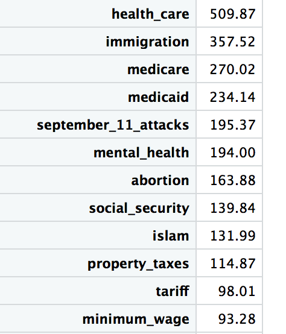

## Additional Analysis

#### **Linear Regression**

Using a merged dataset with the searched topics and vote results, we ran linear regressions to examine the linear relationship between all searched topics and the number of votes for the two different candidates across counties and districts in Texas.

We wanted to examine if there was a relationship between the searched topics (health care, immigration, medicaid, medicare, and September 11 attacks) and actual vote results for the candidates.

In our models, we used the variable for candidates’ poll counts as our continuous outcome, and one of the five searched topics as our predictor. We ran the models individually with one searched topic at a time.

Below is the r-code for linear regression analysis:

```r
#Number of votes for each candidate with health care as predictor

lm_o_hc = lm(o_rourke ~ health_care, data = merged_most_searched) %>% broom::tidy()

lm_cruz_hc = lm(cruz ~ health_care, data = merged_most_searched) %>% broom::tidy()
```

```r
#Number of votes for each candidate with immigration as predictor

lm_o_immigration = lm(o_rourke ~ immigration, data = merged_most_searched) %>% broom::tidy()

lm_cruz_immigration = lm(cruz ~ immigration, data = merged_most_searched) %>% broom::tidy()
```

```r
#Number of votes for each candidate with medicaid as predictor

lm_o_caid = lm(o_rourke ~ medicaid, data = merged_most_searched) %>% broom::tidy()

lm_cruz_caid = lm(cruz ~ medicaid, data = merged_most_searched) %>% broom::tidy()
```

```r
#Number of votes for each candidate with medicare as predictor

lm_o_care = lm(o_rourke ~ medicare, data = merged_most_searched) %>% broom::tidy()

lm_cruz_care = lm(cruz ~ medicare, data = merged_most_searched) %>% broom::tidy()
```

```r
#Number of votes for each candidate with September 11 attacks as predictor

lm_o_911 = lm(o_rourke ~ september_11_attacks, data = merged_most_searched) %>% broom::tidy()

lm_cruz_911 = lm(cruz ~ september_11_attacks, data = merged_most_searched) %>% broom::tidy()
```

#### **Fisher’s Exact Test**

We used a Fisher’s exact test to examine the relationship between topics searched and political party. A Fisher’s Exact Test was ran as opposed to a standard Chi-Squared Test as some of the cells in our dataset were below the expected count.

We wanted to examine if the most searched topics (health care, immigration, medicaid, medicare, September 11 attacks) were related to which political party the counties voted for.

All counties were pooled together, such that we created a 2X5 table with the first row representing the search results for counties that voted for Ted Cruz and the second row representing the search results for counties that voted for Beto O’Rourke.

Below is the r-code for Fisher’s Exact Test:

```r
#Cleaning the data before performing analysis

pre_chisquare_df = merged_nyt_searches %>%
  select(county, x2003_invasion_of_iraq:womens_health, cruz, o_rourke, dikeman ) %>%
  mutate(cruz_orour_rat = cruz/o_rourke,
         status = as.numeric(cruz_orour_rat>=1),
         winner = ifelse(status==1, "Ted Cruz", "Beto O'Rourke")) %>%
  select(-county, -cruz, -dikeman, -o_rourke, -cruz_orour_rat, -winner)

#there are 309 observations initially to account for the county/district combos. 129 topics. Our election results are based on county, thus despite a particular county having differ search counts, the election result will be the same and thus the count can be totalled.
```

```r
#Making a new dataframe for chi-squared analysis

cruz = pre_chisquare_df %>%
  filter(status==1)

cruz = data.frame(winner="Cruz", t(colSums(cruz))) %>%
  select(-status)

o_rourke = pre_chisquare_df %>%
  filter(status==0)

o_rourke = data.frame(winner="O'Rourke", t(colSums(o_rourke))) %>%
  select(-status)

chi_square_df = bind_rows(cruz, o_rourke)

chi_square_df[2:130] = lapply(chi_square_df[2:13], as.integer)
chi_square_df = chi_square_df %>%
  select(health_care, immigration, medicaid, medicare, september_11_attacks)
```

```r
#Results of fisher exact chi squared test

fisher.test(chi_square_df)
```

[output not shown]

## Discussion

#### **Linear Regression**

- Top five searched topics across counties: Health care, Immigration, Medicaid, Medicare and September 11th attacks.
- For the most widely searched topic of Health care, for every one unit increase in search frequency, on average, the number of votes for O’Rourke increases by 118, and the number of votes for Cruz increases by 118. With a p value of 0.938 and 0.909 respectively, these findings are not statistically significant at a level of significance of 0.05.
- For the second most widely searched topic of Immigration, for every one unit increase in search frequency, on average, the number of votes for O’Rourke increases by 14426 and the number of votes for Cruz increases by 10162. Both of these values are statistically significant with p values of 0.000000244 and 0.0000000883, respectively.
- For Medicare, the third most widely searched topic, did not have significant p values for either candidate. However, as the search frequency for this topic increases, the number of votes for both candidates decreases, with O’Rourke receiving 2612 fewer votes and Cruz receiving 1643 fewer votes, on average. For Medicaid, the fourth most widely searched topic did not have significant p values for either candidate. However, as the search frequency for this topic increases, the number of votes for O’Rourke increased by 3.48, while Cruz received 304 votes on average.
- For the fifth most widely search topic of September 11th attacks, for every one unit increase in search frequency, on average, the number of votes for O’Rourke increases by 13479 and the number of votes for Cruz increases by 10235. With a p value of 0.0220 and 0.0106 respectively, these findings are statistically significant at a level of significance of 0.05.
- Comparing the slopes for each model, it appears that there is no difference in the number of votes that either candidate receives, based on frequency of healthcare searches. There is a difference in number of votes that candidates receive based on Medicaid and Medicare search frequency, however this is not statistically significant. However, it appears that there may be a significant difference in the number of votes for either candidate, based on frequency of immigration and September 11th searches. This would need to be confirmed with further statistical testing.
- These findings are not exactly what we expected. We expected that for the top five search terms, as frequency of searches increased, there would be a clearer trend in the number of votes for either candidate. For example, as health care searches increased, the number of votes that O’Rourke might receive would be clearly and significantly larger than the number of votes that Cruz would receive. These findings require further exploration of underlying trends. For example, it may be that despite an increase in number of healthcare searches, this does not necessarily translate into individuals who go out and vote nor does it indicate which candidate voters prefer. Additional information, such as surveys of voter preferences and the intentions of individuals who perform searches, might help inform future analyses.

#### **Fisher’s Exact Test**

- The results of the Fisher’s Exact Test were not statistically significant at the alpha=0.05 level (p=0.1008). Given this result, we have insufficient evidence to conclude that there is a relationship between political party and the most searched topics (health care, immigration, medicaid, medicare, September 11 attacks).
- Therefore, it seems that these particular topics are equally of interest regardless of political ideation. If instead we had analyzed topics that we believe are relevant to a rural vs. urban area, we may have had significant results because usually there is a vast difference in political ideology between these geographies.
- However, given the how the Google trend data is framed, we noticed that it would be difficult to compare geographies that may be distinctly different in size, as a bigger population will result in more topic searches overall.